# Lab5

Hope Hahn

2023-02-08

This week’s lab is a musical lab. You’ll be requesting data from the Spotify API and using it to build k-nearest neighbor and decision tree models.

In order to use the Spotify API you must have a Spotify account. If you don’t have one, sign up for a free one here: https://www.spotify.com/us/signup

Once you have an account, go to Spotify for developers (https://developer.spotify.com/) and log in. Click the green “Create a Client ID” button to fill out the form to create an app so you can access the API.

On your developer dashboard page, click on the new app you just created. Go to Settings -> Basic Information and you will find your Client ID . Click “View client secret” to access your secondary Client ID. Scroll down to Redirect URIs and enter: http://localhost:1410/

You have two options for completing this lab.

**Option 1**: **Classify by users**. Build models that predict whether a given song will be in your collection vs. a partner in class. This requires that you were already a Spotify user so you have enough data to work with. You will download your data from the Spotify API and then exchange with another member of class.

**Option 2**: **Classify by genres**. Build models that predict which genre a song belongs to. This will use a pre-existing Spotify dataset available from Kaggle.com (https://www.kaggle.com/datasets/mrmorj/dataset-of-songs-in-spotify)

Client ID and Client Secret are required to create and access token that is required to interact with the API. You can set them as system values so we don’t have to do provide them each time.

```r
Sys.setenv(SPOTIFY_CLIENT_ID = "224890f1750c4bc0a087829f7573f804")
Sys.setenv(SPOTIFY_CLIENT_SECRET = "5e163d8044d64992b1d1518e1f933bbf")

authorization_code <- get_spotify_authorization_code(scope = scopes()[c(1:19)])  #sets an authorization code that you'll need to provide for certain get_ functions via my_tracks <- get_my_saved_tracks(authorization = authorization_code)

access_token <- get_spotify_access_token()  #takes ID and SECRET, sends to Spotify and receives an access token
```

**Option 1: Data Preparation**

```r
# create vector of offset values we want
offset_vector <- c(0, 50, 100, 150)
# initialize empty data frame
my_tracks200 <- data.frame()

# create for loop to get 200 saved songs
for (i in offset_vector) {

    my_tracks50 <- get_my_saved_tracks(limit = 50, authorization = authorization_code,
        offset = i)
    my_tracks200 <- bind_rows(my_tracks200, my_tracks50)

}
```

Once you have your tracks, familiarize yourself with this initial dataframe. You’ll need to request some additional information for the analysis. If you give the API a list of track IDs using get_track_audio_features(), it will return an audio features dataframe of all the tracks and some attributes of them.

These track audio features are the predictors we are interested in, but this dataframe doesn’t have the actual names of the tracks. Append the ‘track.name’ column from your favorite tracks database.

```r
# create list of only track ID but has to be by 100
# get_track_audio_features only does 100 max
my_tracks_id1 <- my_tracks200 %>%
    head(100)
my_tracks_id2 <- my_tracks200 %>%
    tail(100)

# get track audio features for each 100
features1 <- get_track_audio_features(my_tracks_id1$track.id)
features2 <- get_track_audio_features(my_tracks_id2$track.id)

# combine features into one dataframe
features_all <- bind_rows(features1, features2)

# select track.name and track ID from initial dataframe to
# add to features dataframe
my_tracks200_new <- my_tracks200 %>%
    select(track.name, track.id) %>%
    rename(id = track.id)

# add track.name to features dataframe
my_tracks_final <- left_join(features_all, my_tracks200_new) %>%
    mutate(person = "Hope Hahn")

# save as csv to share with partner in class
# write.csv(my_tracks_final, here::here('labs',
# 'eds232_lab5_HHAHN.csv'))
```

Find a class mate whose data you would like to use. Add your partner’s data to your dataset. Create a new column that will contain the outcome variable that you will try to predict. This variable should contain two values that represent if the track came from your data set or your partner’s.

```r
# reading in ben's dataset
ben_music <- read_csv(here::here("labs", "ben_tracks.csv"))

# add ben's name to his data & combine with my music
hope_ben <- ben_music %>%
    mutate(person = "Ben Versteeg") %>%
    rbind(my_tracks_final) %>%
    select(-c(type, id, uri, track_href, analysis_url, track.name)) %>%
    mutate(time_signature = as.factor(time_signature), person = as.factor(person),
        mode = as.factor(mode), key = as.factor(key))
```

### **Modeling**

You will eventually create four final candidate models:

1. k-nearest neighbor (Week 5)
2. decision tree (Week 5)
3. bagged tree (Week 6)
- bag_tree()
- Use the “times =” argument when setting the engine during model specification to specify the number of trees. The rule of thumb is that 50-500 trees is usually sufficient. The bottom of that range should be sufficient here.
4. random forest (Week 6)
- rand_forest()
- m_try() is the new hyperparameter of interest for this type of model. Make sure to include it in your tuning process

Go through the modeling process for each model:

Preprocessing. You can use the same recipe for all the models you create.

Resampling. Make sure to use appropriate resampling to select the best version created by each algorithm.

Tuning. Find the best values for each hyperparameter (within a reasonable range).

Compare the performance of the four final models you have created.

Use appropriate performance evaluation metric(s) for this classification task. A table would be a good way to display your comparison. Use at least one visualization illustrating your model results.

### Preprocessing for all models

**Prepare data and create recipe for all models.**

```r
# initial split of data
music_split <- initial_split(hope_ben, prop = 0.7)
music_test <- testing(music_split)
music_train <- training(music_split)

# create recipe
music_recipe <- recipe(person ~ ., data = music_train) %>%
    step_dummy(all_nominal(), -all_outcomes(), one_hot = TRUE) %>%
    step_normalize(all_numeric(), -all_outcomes())

# 10-fold CV on the training dataset
cv_folds <- music_train %>%
    vfold_cv(v = 10)
```

### K-Nearest Neighbors

```r
## Create model specification and workflow ----

# specify k nearest neighbors model
knn_spec <- nearest_neighbor(neighbors = tune()) %>%
  set_engine("kknn") %>%
  set_mode("classification")

# save workflow to object
knn_workflow <- workflow() %>%
  add_model(knn_spec) %>%
  add_recipe(music_recipe)

## Tune parameters ----
# parameter tuning
fit_knn_cv <- knn_workflow %>%
  tune_grid(resamples = cv_folds,
            grid = data.frame(neighbors = c(1,5,seq(10,100,10))))

## Finalize and model fitting ----
# finalize the workflow to choose best model
final_wf_knn <- knn_workflow %>%
  finalize_workflow(select_best(fit_knn_cv, metric = "accuracy"))

# fit model to training set
train_fit_knn <- fit(final_wf_knn, music_train)

# predict train data
train_predict_knn <- predict(object = train_fit_knn, new_data = music_train) %>% #predict the training set
  bind_cols(music_train) #bind training set column to prediction

# predict test data
test_predict_knn <- predict(train_fit_knn, music_test) %>% #get prediction probabilities for test data
  bind_cols(music_test) %>%  #bind to testing column
  mutate(person <- as.factor(person))

# test accuracy
#accuracy(train_predict_knn, truth = person, estimate = .pred_class)
accuracy_knn <- accuracy(test_predict_knn, truth = person, estimate = .pred_class)
```

*Visualize KNN Performance*

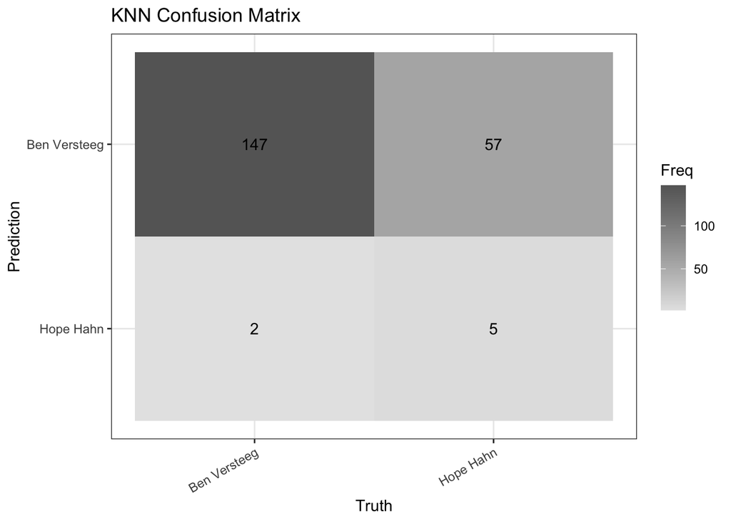

```r
# plot confusion matrix
test_predict_knn %>%
  conf_mat(truth = person, estimate = .pred_class) %>% #create confusion matrix
  autoplot(type = "heatmap") + #plot confusion matrix with heatmap
  theme_bw() + #change theme
  theme(axis.text.x = element_text(angle = 30, hjust=1)) +
  #rotate axis labels
  labs(title = "KNN Confusion Matrix")
```

**The accuracy of the KNN model is 0.7203791, meaning that the model only correctly predicts about three quarters of the test data correctly.**

### Decision Tree

```r
# model specification
tree_spec <- decision_tree(
  cost_complexity = tune(),
  tree_depth = tune(),
  min_n = tune()) %>%
  set_engine("rpart") %>%
  set_mode("classification")

tree_grid <- grid_regular(cost_complexity(), tree_depth(), min_n(), levels = 5)

# create workflow
wf_tree <- workflow() %>%
  add_recipe(music_recipe) %>%
  add_model(tree_spec)

doParallel::registerDoParallel() #build trees in parallel
#200s

  tree_rs <- tune_grid(
    wf_tree,
    resamples = cv_folds,
    grid = tree_grid,
    metrics = metric_set(accuracy)
  )


# finalize the workflow to select the best tree
final_wf_tree <- finalize_workflow(wf_tree, select_best(tree_rs))

# fit the train data to model
final_fit_tree <- fit(final_wf_tree, data = music_train)

# predict train data
train_predict_tree <- predict(object = final_fit_tree, new_data = music_train) %>% #predict the training set
  bind_cols(music_train) #bind training set column to prediction

# predict test data
test_predict_tree <- predict(final_fit_tree, music_test) %>% #get prediction probabilities for test data
  bind_cols(music_test) %>%  #bind to testing column
  mutate(person <- as.factor(person))

# test accuracy
#accuracy(train_predict_tree, truth = person, estimate = .pred_class)
accuracy_tree <- accuracy(test_predict_tree, truth = person, estimate = .pred_class)
```

*Visualize Decision Tree Performance*

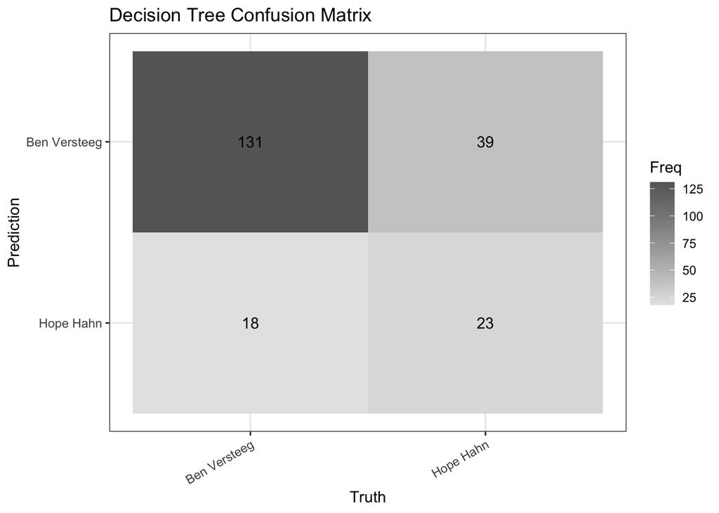

```r
# plot confusion matrix
test_predict_tree %>%
  conf_mat(truth = person, estimate = .pred_class) %>% #create confusion matrix
  autoplot(type = "heatmap") + #plot confusion matrix with heatmap
  theme_bw() + #change theme
  theme(axis.text.x = element_text(angle = 30, hjust=1)) +
  #rotate axis labels
  labs(title = "Decision Tree Confusion Matrix")
```

**The accuracy of the decision tree model is 0.7298578, which means that this model also only predicts about three quarters of the test data correctly.**

### Bagged Tree

```r
# set model specification
bag_model <- bag_tree(cost_complexity = 0,
                      tree_depth = NULL,
                      min_n = tune(),
                      class_cost = NULL) %>%
  set_engine("rpart", times = 100) %>%
  set_mode("classification")

# set workflow
bag_wf <- workflow() %>%
  add_model(bag_model) %>%
  add_recipe(music_recipe)

# tune parameters
bag_cv_tune <- bag_wf %>%
  tune_grid(
    cv_folds,
    grid = expand_grid(min_n=c(10,20,50)),
    metrics = metric_set(accuracy))

# finalize workflow
bag_final <- finalize_workflow(bag_wf,
                               select_best(bag_cv_tune, metric = "accuracy"))

# fit train data to model
train_fit_bag <- fit(bag_final, music_train)

# predict train data
train_predict_bag <- predict(object = train_fit_bag, new_data = music_train) %>% #predict the training set
  bind_cols(music_train) #bind training set column to prediction

# predict test data
test_predict_bag <- predict(train_fit_bag, music_test) %>% #get prediction probabilities for test data
  bind_cols(music_test) %>%  #bind to testing column
  mutate(person <- as.factor(person))

# test accuracy
#accuracy(train_predict_bag, truth = person, estimate = .pred_class)
accuracy_bag <- accuracy(test_predict_bag, truth = person, estimate = .pred_class)
```

*Visualize Bagging Performance*

[figure not shown]

```r
# plot confustion matrix
test_predict_bag %>%
  conf_mat(truth = person, estimate = .pred_class) %>% #create confusion matrix
  autoplot(type = "heatmap") + #plot confusion matrix with heatmap
  theme_bw() + #change theme
  theme(axis.text.x = element_text(angle = 30, hjust=1)) +
  #rotate axis labels
  labs(title = "Random Forest Confusion Matrix")
```

**The accuracy of the bagging model is 0.7440758. This model performs better than the previous two, but still only predicts about three quarters of the test data correctly.**

### Random Forest

```r
# create model specification
rf_model <- rand_forest(mtry = tune(),
                        trees = tune()) %>%
  set_engine("ranger") %>%
  set_mode("classification")

# create workflow
rf_workflow <- workflow() %>%
  add_model(rf_model) %>%
  add_recipe(music_recipe)

# tune paramaters
rf_cv_tune <- rf_workflow %>%
  tune_grid(resamples = cv_folds, grid = 10)

# finalize workflow to select best model
rf_final <- finalize_workflow(rf_workflow,
                              select_best(rf_cv_tune, metric = "accuracy"))

# fit train data to model
train_fit_rf <- fit(rf_final, music_train)

# predict train data
train_predict_rf<- predict(object = train_fit_rf, new_data = music_train) %>% #predict the training set
  bind_cols(music_train) #bind training set column to prediction

# predict test data
test_predict_rf <- predict(train_fit_rf, music_test) %>% #get prediction probabilities for test data
  bind_cols(music_test) %>%  #bind to testing column
  mutate(person <- as.factor(person))

# test accuracy
#accuracy(train_predict_rf, truth = person, estimate = .pred_class)
accuracy_rf <- accuracy(test_predict_rf, truth = person, estimate = .pred_class)
```

*Visualize Random Forest Performance*

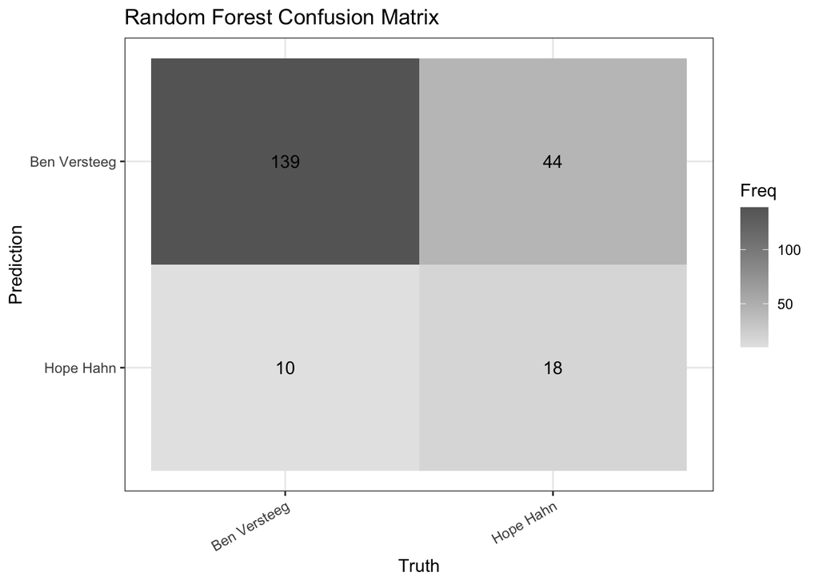

```r
# plot confustion matrix
test_predict_rf %>%
  conf_mat(truth = person, estimate = .pred_class) %>% #create confusion matrix
  autoplot(type = "heatmap") + #plot confusion matrix with heatmap
  theme_bw() + #change theme
  theme(axis.text.x = element_text(angle = 30, hjust=1)) +
  #rotate axis labels
  labs(title = "Random Forest Confusion Matrix")
```

### Comparing Models

```r
# create data frame of accuracy
accuracy_df <- data.frame(model = c("KNN", "Decision Tree", "Bagging",
    "Random Forest"), test_accuracy = c(accuracy_knn$.estimate,
    accuracy_tree$.estimate, accuracy_bag$.estimate, accuracy_rf$.estimate))

# accuracy Table
kable(accuracy_df, caption = "Accuracy of Each Model")
```

Accuracy of Each Model

| model | test_accuracy |
| --- | --- |
| KNN | 0.7203791 |
| Decision Tree | 0.7298578 |
| Bagging | 0.7440758 |
| Random Forest | 0.7440758 |